# Going Bayesian

Jasper Slingsby

## Going Bayesian

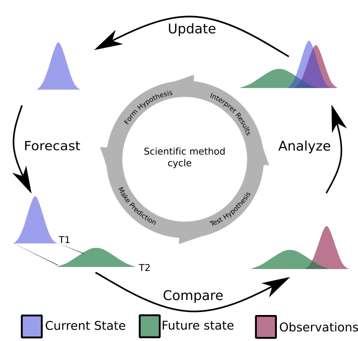

The iterative ecological forecasting cycle in the context of the scientific method, demonstrating how we stand to learn from making iterative forecasts.

- Iterative ecological forecasting presents new challenges not common in the world of null hypothesis testing that has dominated ecology to date…
- It is much easier to deal with these in a Bayesian framework.
- Here I provide a brief and (relatively) soft introduction to Bayesian statistical theory.

## Advantages of Bayesian approaches

1. They **focus on estimating what properties are**
   - i.e. the actual value of parameters, not just establishing that they are different to a null expectation as in *null hypothesis testing*
2. They are highly **flexible**, allowing **complex models with varied data sources**, especially Hierarchical Bayesian models
3. They can treat all terms as probability distributions, making it **easier to quantify, propagate and partition uncertainties throughout the analysis**, allowing one to:
   - **present uncertainty** in the forecast to the decision maker
   - **analyze the uncertainty**, guiding improvements
4. They provide an **iterative** probabilistic framework that allows us to learn from new evidence (data) in the context of existing (*prior*) knowledge.
   - This makes it easier to update predictions as new data become available, completing the forecasting cycle.

## But first…

**Before I can introduce Bayes**, there are a few basic building blocks we need to establish first.

1. How the method of *Least Squares* works, and its limitations, especially it’s inflexible, implicit data model.
2. The concept of *likelihood* and the method of maximum likelihood estimation
   - this is a major component of Bayes’ Theorem
   - its a frequentist method, but has the advantages 1 & most of 2 above
     - in fact, there are frequentist approaches for doing much of the advantages listed on the previous slide, but they are typically cumbersome. Bayes you can do it all without much extra work.

## Least Squares

Traditional parametric statistics like regression analysis and analysis of variance (ANOVA) rely on *Ordinary Least Squares (OLS)*.

There are other flavours of least squares that allow more flexibility (e.g. nonlinear (NLS) that we used in the practical, partial least squares, etc), but I’m not going to go into these distinctions.

## Least Squares

In general, least squares approaches “fit” (i.e. estimate the parameters of) models by **minimizing the sums of the squared residuals**.

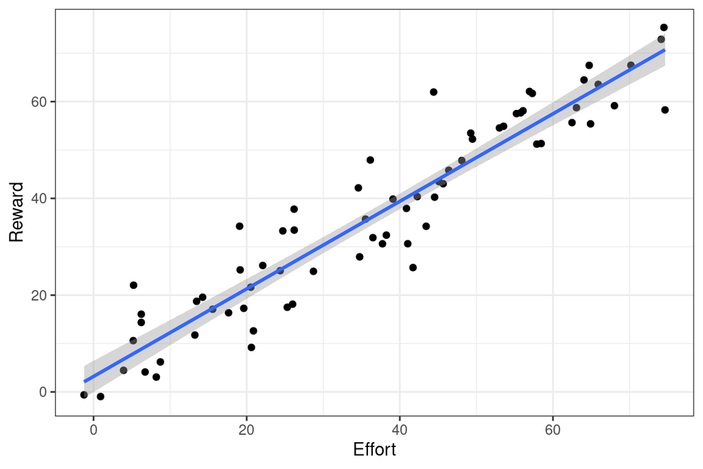

The model (blue line) is drawn through the points to minimize the sum of the squared vertical (y-axis) differences between each point and the regression line (i.e. residuals).

Redrawn highlighting the residuals:

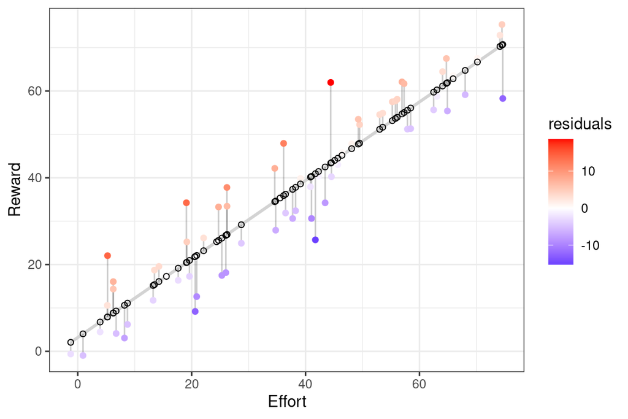

- The residuals are the grey lines (lollypop sticks) linking each observed data point to the values predicted by the model (open circles along the regression line)
- They are **vertical and not orthogonal** to the regression line, because they represent the variance in Y (*Reward*) that is not explained by X (*Effort*)
- There is no scatter in the predicted values (open circles), because the scatter is **residual variance that the model cannot account for and predict**.

A histogram of the residuals:

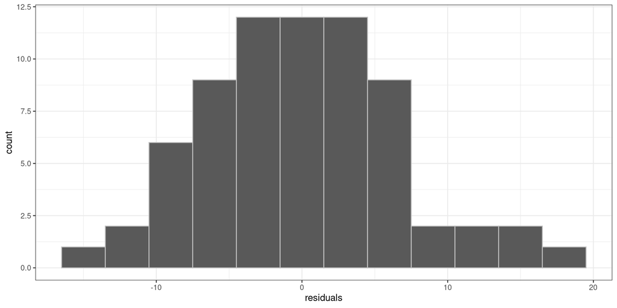

The residuals approximate a *normal distribution*

This is a **key assumption** when using Least Squares

- termed “homoscedasticity” or “homogeneity of variance”
- For minimizing the sums of squares to work, a unit change in the residuals should be *scale invariant*
  - i.e. the difference between 1 and 2 or 101 and 102 must be the same
  - This is only true when the residuals are normally distributed (versus log-scale for example)
  - If not, **minimizing the sums of squares does not work** (and people often try to log transform etc their data to get them to an invariant scale).
- If violated, consider a different process model (i.e. nonlinear), or another statistical approach (MLE or Bayes).

## The shortcomings of Least Squares:

*1. Least Squares doesn’t explicitly include a data model*

It’s useful at this stage to make a distinction between data models and process models.

- The *process model* is the bit you’ll be used to, where we describe how the model creates a prediction for a particular set of inputs or covariates (e.g. a linear model)
- The *data model* describes the residuals (i.e. mismatch between the process model and the data)
  - also often called the data observation process

> Least Squares analyses don’t explicitly include a data model, because minimizing the sums of squares means that *the data model in a Least Squares analysis can only ever be a normal distribution* (i.e. there must be homogeneity of variance)

## Why is this a limitation?

1. in reality, the *data model can take many forms*
   - e.g. Binomial coin flips, Poisson counts of individuals, Exponential waiting times, etc
   - this is where Maximum Likelihood comes into it’s own
     - recall in the practical we specified two functions for the MLE analyses:
       - the *process model* (`pred.negexp/S`)
       - the likelihood function (`fit.negexp/S.MLE`), including the *data model*
2. sometimes one would like to *include additional information in the data model*
   - e.g. sampling variability (e.g. different observers or instruments), measurement errors, instrument calibration, proxy data, unequal variances, missing data, etc
   - this is where Bayesian models come into their own

## The shortcomings of Least Squares:

*2. Least squares focuses on what the parameters are not, rather than what they are*

- Least Squares focuses on *null hypothesis testing* - the ability to reject (or to fail to reject) the null hypothesis at some threshold of significance (alpha; usually P < 0.05)
- For a linear model, *the null hypothesis is that the slope = 0 (i.e. no effect of X on Y)*
- A linear model is only considered useful when you can reject the null hypothesis.
  - This just tells you that the probability of the parameter of interest (the slope in this case) being 0 is very low…
- It *tells you nothing about the probability of the parameters actually being the estimates you arrives at by minimizing the sums of squares*!!!?

## Maximum likelihood

*The likelihood principle* = parameter value is more likely than another if it is the one for which the data are more probable.

*Maximum Likelihood Estimation (MLE)* = a method for estimating model parameters by applying the likelihood principle. It optimizes parameter values to maximize the likelihood that the process described by the model produced the data observed.

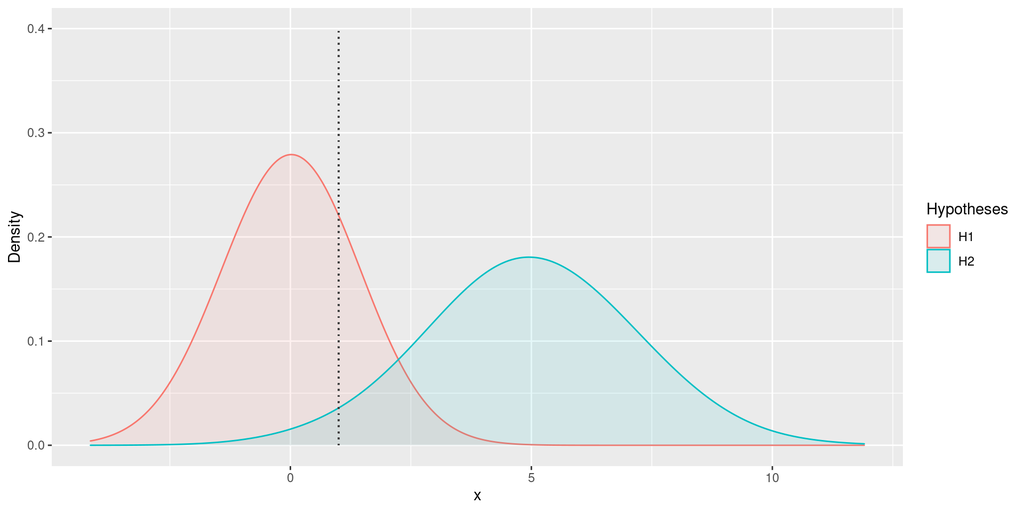

## Maximum likelihood

Viewed differently…

With MLE we assume we have the correct model and use MLE to choose parameter values that maximize the *conditional probability* of the data given those parameter values, $P(Data|Parameters)$.

- This leaves us knowing the likelihood of the best set of parameters and the conditional probability of the data given those parameters $P(Data|Parameters)$

BUT!

**What we really want is to know is the conditional probability of the parameters given the data** $P(Parameters|Data)$, because this allows us to *express uncertainty in the parameter estimates as probabilities*.

- To get there, we apply a little probability theory, with a surprisingly useful byproduct!

## Conditional probability

We can also define two *conditional probabilities*:

- the probability of $x$ given $y$, $P(x|y)$
- the probability of $y$ given $x$, $P(y|x)$

- the probability of being in set $x$ given we are only considering points in set $y$ (= 3/6)
- the probability of being in set $y$ given we are only considering points in set $x$ (= 3/7)

## Marginal probability

Last, we can define two *marginal probabilities* for $x$ and $y$.

These are just the separate probabilities of being in set $x$ or being in set $y$ given the full set of events, i.e.

- $P(x)$ = 7/10 and
- $P(y)$ = 6/10

### Joint, conditional and marginal probabilities

We can also show that the joint probabilities are the product of the conditional and marginal probabilities:

$$P(x,y) = P(x|y) P(y) = 3/6 * 6/10 = 0.3$$

And by the same token:

$$P(y,x) = P(y|x) P(y) = 3/7 * 7/10 = 0.3$$

Tadaa!

This means we can derive what we want to know, $P(Parameters|Data)$, as a function of the information maximum likelihood estimation provides, $P(Data|Parameters)$.

…Let’s do this derivation…

## Bayes’ Theorem

Now let:

- parameters = $\theta$
- the data = $D$

We’re interested in the conditional probability of the parameters given the data, $p(\theta|D)$.

To get this, we need to take the previous equations and solve for $p(\theta|D)$.

Since we know the joint probabilities are identical:

$$p(\theta,D) = p(\theta|D)p(D)$$

$$p(D,\theta) = p(D|\theta)p(\theta)$$

We can take the right hand side of the two:

$$p(\theta|D)p(D) = p(D|\theta)p(\theta)$$

and solve for $p(\theta|D)$ as:

$$p(\theta|D) = \frac{p(D|\theta) \; p(\theta)}{p(D)} \;\;$$

which is known as Bayes’ Theorem!

## Bayes’ Theorem

Rewriting the terms on one line allows us to label them with their names:

$$\underbrace{p(\theta|D)}_\text{posterior} \; = \; \underbrace{p(D|\theta)}_\text{likelihood} \;\; \underbrace{p(\theta)}_\text{prior} \; / \; \underbrace{p(D)}_\text{evidence}$$

### The *evidence*

The marginal probability of the data, $p(D)$, is now called the *evidence* for the model, and represents the overall probability of the data according to the model.

- having $p(D)$ in the denominator means it normalizes the numerators to ensure that the updated probabilities sum to 1 over all possible parameter values - i.e. it ensures that the posterior, $p(\theta|D)$, is expressed as a probability distribution
- $p(D)$ can otherwise mostly be ignored and is often left out, resulting in…

## Bayes’ Rule

Getting rid of the evidence allows us to focus on the important bits:

$$\underbrace{p(\theta|D)}_\text{posterior} \; \propto \; \underbrace{p(D|\theta)}_\text{likelihood} \;\; \underbrace{p(\theta)}_\text{prior} \;$$

Which reads *“The posterior is proportional to the likelihood times the prior”.*

This leaves us with three terms:

### The *likelihood*

$p(D|\theta)$ still represents the probability of the data given the model with parameter values $\theta$, and is used in analyses to find the likelihood profiles of the parameters.

## Bayes’ Rule

$$\underbrace{p(\theta|D)}_\text{posterior} \; \propto \; \underbrace{p(D|\theta)}_\text{likelihood} \;\; \underbrace{p(\theta)}_\text{prior} \;$$

### The *posterior*

- What we have been calling the conditional probability of the parameters given the data, $p(\theta|D)$, is now called the *posterior*
- It gives us a probability distribution for the values any parameter can take, *allowing us to represent uncertainty in the model and forecasts as probabilities*, which is the holy grail we were after!!!
  - i.e. the posterior(s) is/are the parameter(s) of interest that we forecast, and we can now indicate the probability of our forecast being correct

## Bayes’ Rule

$$\underbrace{p(\theta|D)}_\text{posterior} \; \propto \; \underbrace{p(D|\theta)}_\text{likelihood} \;\; \underbrace{p(\theta)}_\text{prior} \;$$

### The *prior*

- The marginal probability of the parameters, $p(\theta)$, is now called the *prior*.
- While $p(\theta)$ is almost an unexpected consequence of having solved the equation for $p(\theta|D)$, *the prior is where a lot of the magic of Bayes lies!*
- Firstly, we know that $p(\theta)$ is a necessary requirement for us to be able to represent the posterior, $p(\theta|D)$, as a probability distribution (what we were looking for).
- But, it also represents *the credibility of the parameter values, $\theta$, without the data, $D$*.
  - What does this mean?

## The prior

> The prior represents the credibility of the parameter values, $\theta$, without the data, $D$.

> *“But how can we know anything about the parameter values without the data?”*

By applying *the scientific method*, whereby we interrogate new evidence (the data) in the context of previous knowledge or information to update our understanding.

- $p(\theta)$ is the *prior belief* of what the parameters should be, before interrogating the data
  - i.e. our “context of previous knowledge or information”
- if we don’t have much previous knowledge, we can specify the prior to represent that
- the prior is incredibly powerful! But the [Peter Parker Principle](https://en.wikipedia.org/wiki/With_great_power_comes_great_responsibility) applies - *“With great power comes great responsibility!”*

## The power of the prior

1. It allows Bayesian analyses to be *iterative*. The posterior from one analysis can become the prior for the next!
   - This provides *a formal probabilistic framework for the scientific method!*
     - New evidence must be considered in the context of previous knowledge, providing the opportunity to update our beliefs.
   - This is *ideal for iterative forecasting*, because the previous forecast can be the prior for the next.

## The power of the prior

2. It makes Bayesian models *incredibly flexible*, allowing us to specify complex hierarchical models in a completely probabilistic framework relatively intuitively.
   - This is fantastic for “fusing” disparate data sources!
     - E.g. we may not have “prior beliefs” about a parameter’s values, but we may know something about another parameter or process that influences it. If so, we can specify a prior on our prior (called a *hyperprior*).
   - We can also specify separate or linked priors (or hyperpriors) for different parameters (or priors).

### The prior comes with great responsibility…

> It is very easy to specify an inappropriate prior and bias the outcome of your analysis!
- First and foremost, as tempting as it may be, *the one place the prior CANNOT come from is the data used in the analysis!!!*
- Second, while many people favour specifying “uninformative” priors, it is often **incredibly difficult to know what “uninformative”** is for different models or parameters.
  - [Here’s a great Guardian article](https://www.theguardian.com/world/2021/apr/18/obscure-maths-bayes-theorem-reliability-covid-lateral-flow-tests-probability) on why considering priors are important for Covid testing and criminal cases. It should help you get your head around this.

We’ll get stuck into examples showing the value of Bayes in ecology in the next lecture.